# Building a shared framework for GenAI

Paulina García-Corral

## Why now?

- First, there has been a shift from methods that involve the manual engineering of text into numerical representations.
- Second, large pre-trained models have led to greater accuracy.
- Third, and more recently, there has been a shift from programming to an interface that uses natural language inputs and outputs.

  (Than et al. 2025)

## Why us?

Before GenAI researchers that were using computational tools for their work had to have *some* understanding of what they were using because the entry barrier has hefty:

[figure not shown]

- Scrape the data
- Annotate the data
- Write the code
- Deal with the computational equipment

## Why us?

The line between using AI as a tool, and studying the tool was a bit more blurry. Three years ago, we became the LLM “experts” because we could code a Python loop that called an API 😂

With the current advances of GenAI, it’s *really* not the same to use AI as a tool in research and researchers who study AI.

## What is computational social science?

What where we studying that made us different from quant, from causal inference, from qual…

What can we retain from all that we learned now that coding is not what makes us special?

## Is this computational social science?

Lowering the technical barrier to use GenAI can mean different things to different people, but when non-computational researchers use GenAI tools, what are the doing *methodologicaly*?

a. Come up with new research ideas? (research design)

b. Pass on their research work to an agent (speed up or automate)

c. Integrate new methods into their research (mix methods)

d. Evaluate their analysis (data saturation checks, triangulation)

e. Prepare and revise manuscripts (write up and edition work)

## Visions of AI

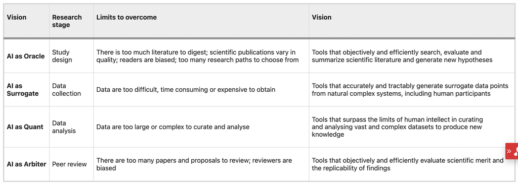

Table 1. Messeri and Crockett (2024)

## *Qualitative* AI work?

When researchers integrate a *new* tool into the workflow, is this a new method? (To what extent is this the same as using Nvivo? What about when Topic Modeling became all the rage?)

People will use Generative AI to answer questions previously reserved for qualitative research, and they will do so within a quantitative paradigm preferred by institutions. This is because AI’s answers to these questions are not really qualitative research, institutions will begin using this version of qualitative research instead. (Horta Ribeiro 2026)

Increasing productivity equal better understanding?

## “Qualitative work can’t be automated” Jowsey et al. (2025)

1. GenAI as simulated intelligence is incapable of meaning-making.
2. Qualitative research should remain a distinctly *human* practice.
3. The established manifold harms of GenAI, especially to the environment and workers in the Global South.

## I think this leaves us with a specific subset of researchers

A new paradigm (Chatzichristos 2025)

- There’s no real inherent interest in becoming a computational scholar (at least not now)
- Better way to use the tool for their own research

We should probably focus on: making learners thoughtful, critical and systematic users of AI, not proficient data scientist.

The alignment with different approaches and their values may shape the application of AI in assisting content analysis (Nicmanis and Spurrier 2025)

## How to get there

We need to build a shared vocabulary, pedagogical framework and cross disciplinary best practices.

## Vocabulary

What do we mean when we say GenAI, LLM, prompt, parameters, & etc…

But also what do we mean when we say coding, label, annotation, themes?

## Pedagogical Framework

All researchers will be teaching students that are using GenAI.

What must we absolutely know to be ready to teach in this new landscape?

As educators, how can we understand what learning *is* when these models are in the middle of the process?

## Cross disciplinary best practices

What are the research standards that are important for each paradigm and how can we meet? Can we meet?

[figure not shown]

## Cross disciplinary best practices

Reproducibility but also flexibility

Scaleble but also context dependent

As reviewers we will get manuscripts that are not meant to be research about GenAI, but that is using some GenAI created measure. How can our expertise be best leveraged to help our colleagues?

## How to engage with non-experts on AI

**Restructure the use and engagement** of GenAI, and move away from using AI passively to get to a place where we convince non-computational researchers that they can and should be interrogating it systematically.

## This implies

1. **Intuition**  
   Understand what LLMs do and why they behave as they do
2. **Interaction**  
   Learn how to work with LLMs beyond chat and copy-paste
3. **Evaluation**  
   Critically assess outputs (bias, limitations, variation)
4. **Documentation**  
   Make the process transparent and reproducible*

## Should qualitative researchers be able to:

- Program?
- Explain what a transformer is?
- Explain LLMs in simple, functional terms?
- Use structured prompts instead of copy and paste from chat bot interfaces?
- Identify common failure modes (bias, hallucination, flattening)?
- Document their workflow for transparency and reproducibility?
- Decide when LLMs are useful?

## Modes of Combining Computation and Qualitative Analysis

A key consideration is how—or whether—to integrate computational tools into the analytical workflow. Researchers adopt different modes based on project needs, data sensitivity, and analytical goals.(Abramson et al. 2025)

## 1. **Streamline (Organizational):**

- Using computational tools to manage the logistics of research—organizing manifests, facilitating de-identification, managing quotes, and tracking team progress—even if the core coding and analysis remain entirely manual.

## 2. **Scale-up (Efficiency/Scope):**

- When the corpus is large, longitudinal, or multi-site, machine learning (e.g., supervised classification) is used to assist human coding. This requires high-quality human-labeled training data and rigorous human checks and validation (e.g., hybrid approaches).

## 3. **Hybrid (Iterative Refinement and Mixed Methods):**

- Interleaving human analysis with computational methods to answer different types of questions or refine understanding. This can involve iterative coding refinement, or using computational patterns (e.g., visualization, network analysis) to identify typologies or variations that guide subsequent in-depth reading and comparison

## 4. **Discovery (Pattern Finding):**

- Utilizing unsupervised methods (e.g., topic modeling, clustering, visualization) to identify latent patterns, themes, or typologies that guide subsequent deep reading and theory development

## 5. **Minimal/No Computation (The “Sociology of Computation”):**

- Deliberately choosing not to automate analysis when ethical considerations, highly specific contexts, small scale, or the nature of the inquiry make automation counterproductive or risky. Documenting the rationale for this choice is practical, given review– explaining reflexivity and decisions has long been central to qualitative inquiry

## What do we want non-computational researchers to know that we would consider enough to establish a shared understanding?

## Creating a shared understanding

Develop a **usable mental model** of LLMs

At a minimum:

- A brief history of how we got here
- LLMs as pattern-based text predictors
- Role of training data and scale
- Why outputs can reflect bias

They distinguish between questions they see as problems of measurement and optimization, and questions they see as requiring interpretation, context, and meaning-making.

## Goal 1: From Chatting to Structured Interaction

Shift from use to experimentation:

- Prompt structure:
  - role
  - instruction
  - context
  - output format
- Parameters

## Teaching strategy

Introduce playground

### Activity

**Prompt comparison**

- Same task, different prompts
- Compare outputs:
  - What changed?
  - Why?

## Goal 2: Systematic Exploration

Teach learners to probe the system:

- Input variation
- Output variability
- Sensitivity to phrasing

## Teaching strategy

Encourage structured experimentation:

- Change one variable at a time

### Activity

**Parameter exploration**

Run the same prompt with different settings

- Observe:
  - consistency vs creativity
  - stability vs drift

## Goal 3: Evaluating Outputs

Develop critical AI literacy, such that scholars are aware of why, what and how there come up:

- Hallucination
- Bias
- Loss of nuance
- Overgeneralization

## Teaching strategy

**Contrast-based learning**

### Activity

**Human vs AI comparison**

1. Learners analyze a text manually
2. AI analyzes the same text
3. Compare:
   - What did AI miss?
   - What did it oversimplify?

## Goal 4: From Ad Hoc Use to Workflow Thinking

Introduce structure and repeatability (here we enter interesting epistemic territory)

- Prompt templates
- Iterative refinement
- Batch thinking (even without code)

## Teaching strategy

Replace copy-paste prompting with structured processes.

### Activity

**Template building**

- Create a reusable prompt for a research task
- Test it across multiple inputs

## Goal 5: Local LLMs

LLM use that’s transparent, local and traceable

- Introduce local models.
- Talk about trade-offs, “no-free lunch” mentality.
- Why are these models reproducible? what does that even mean?

## Teaching Strategy

Use LM studio to test small models at the same time with big models on an API

### Activity

- Compare a big model output with a small model output
- Show the history of models disapearing
- Download them into your own computer (talk about RAM memory etc.)

## Reproducibility & Documentation

- Reproducibility
  - not identical results
  - but inspectable processes
- Importance of documentation:
  - prompts
  - parameters
  - model version

Is reproducibility “Making interpretation visible”?

## Ethics, Responsibility, and Limits

Ethical pitfalls include:

- algorithmic bias
- environmental costs
- public misunderstanding of capabilities of AI
- exploitative labor practices

## Epistemic risks

- Error and hallucinations
- Failures of reproducibility
- Lack of interpretability.

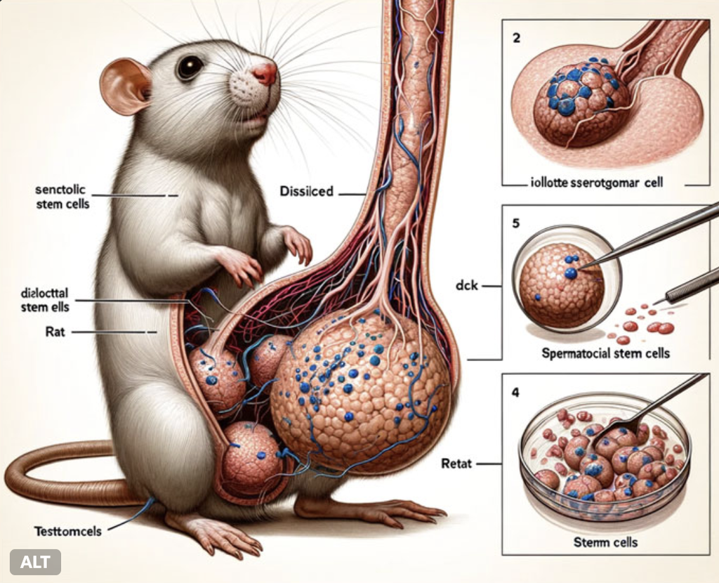

(Guo, Dong & Hao, 2024)

## Epistemic risks in science

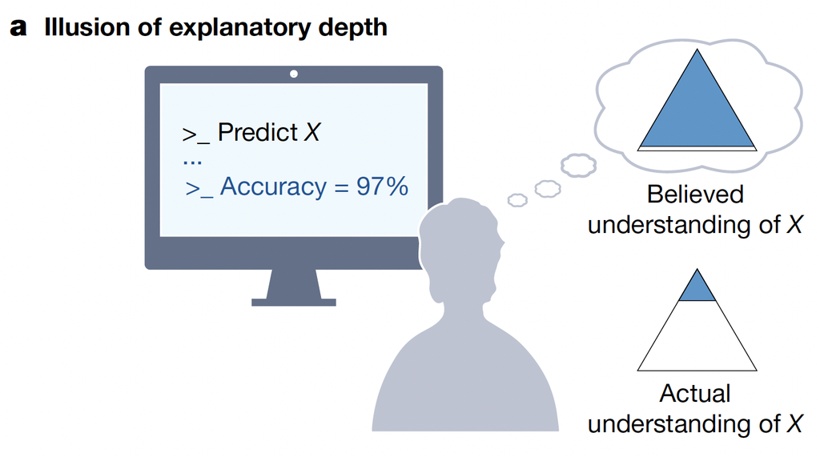

(Messeri & Crockett, 2024)

## Epistemic risks in science

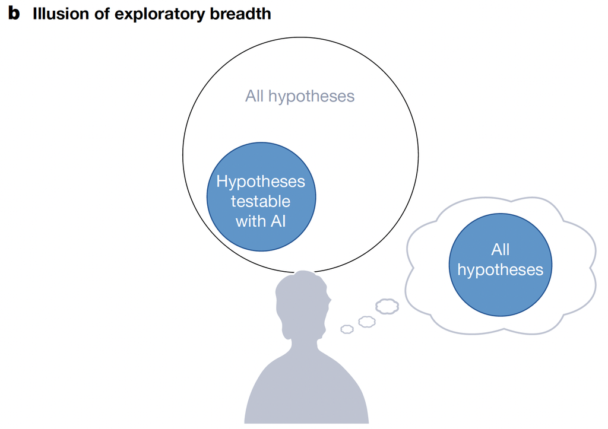

(Messeri & Crockett, 2024)

## Epistemic risks in science

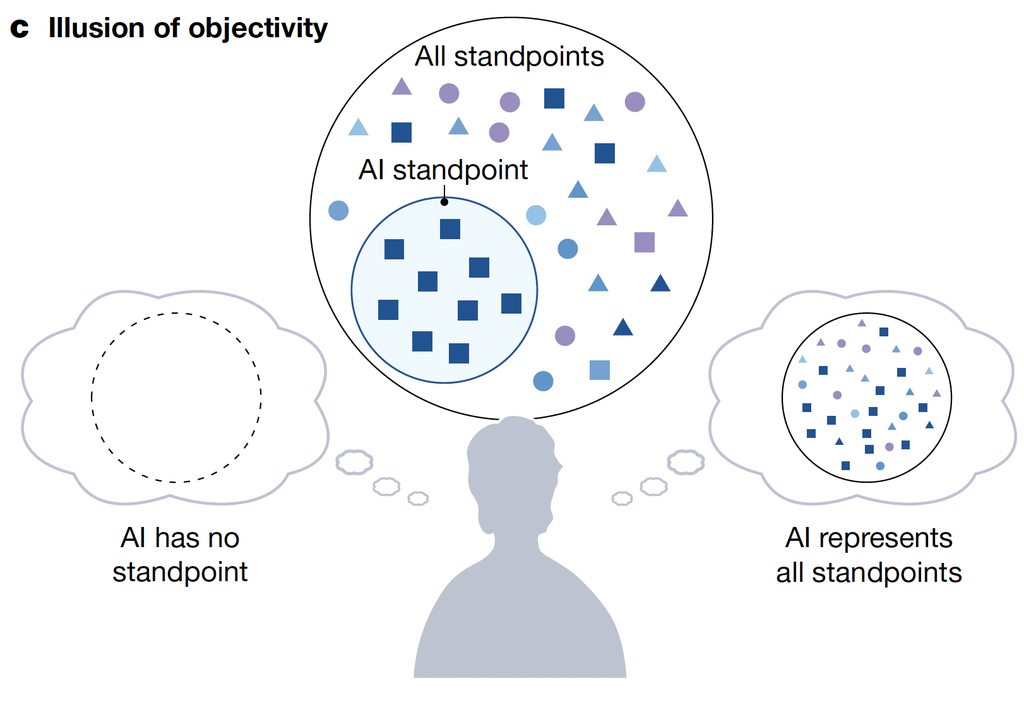

(Messeri & Crockett, 2024)

## Pedagogical Principles

1. Teach through interaction, not explanation
2. Use progressive disclosure
3. Design for productive failure
4. Anchor everything in real tasks
5. Reduce intimidation, enable exploration
6. Emphasize learner expertise

## Teach through interaction, not explanation

- Minimize lecturing
- Maximize hands-on experimentation

## Use progressive disclosure

Teach in layers:

1. What it does
2. When to use it
3. How it works

## Design for productive failure

- Include exercises where AI fails
- Let learners discover limitations

## Anchor everything in real tasks

Never introduce a tool without a use case:

- coding interviews
- summarizing texts
- generating themes

## Reduce intimidation, enable exploration

- Normalize confusion
- Encourage experimentation
- Avoid perfectionism
- Use metaphors

## Emphasize learner expertise

The model generates outputs but the human interprets them.

Evaluate the whole process, not just the output

Good assessment includes:

- Prompt design quality
- Ability to critique outputs
- Documentation completeness
- Reflection on limitations

## Final guiding statement

> The goal is to make researchers **thoughtful, critical, and systematic users of AI**, and not just proficient in it.

## References

Abramson, Corey, Zhuofan Li, Tara Prendergast, and Daniel Dohan. 2025. “Qualitative Research in an Era of AI: A Pragmatic Approach to Data Analysis, Workflow, and Computation.” http://dx.doi.org/10.31235/osf.io/7bsgy_v1.

Chatzichristos, Georgios. 2025. “Qualitative Research in the Era of AI: A Return to Positivism or a New Paradigm?” *International Journal of Qualitative Methods* 24 (April). https://doi.org/10.1177/16094069251337583.

Horta Ribeiro, Manoel. 2026. “Qualitative Research After the Interviewer Bot.” *Doomscrolling Babel*. Substack. https://doomscrollingbabel.manoel.xyz/p/qualitative-research-after-the-interviewer.

Jowsey, Tanisha, Virginia Braun, Victoria Clarke, Deborah Lupton, and Michelle Fine. 2025. “We Reject the Use of Generative Artificial Intelligence for Reflexive Qualitative Research.” *Qualitative Inquiry*, December. https://doi.org/10.1177/10778004251401851.

Messeri, Lisa, and M. J. Crockett. 2024. “Artificial Intelligence and Illusions of Understanding in Scientific Research.” *Nature* 627 (8002): 49–58. https://doi.org/10.1038/s41586-024-07146-0.

Nicmanis, Mitchell, and Harry Spurrier. 2025. “Getting Started with Artificial Intelligence Assisted Qualitative Analysis: An Introductory Guide to Qualitative Research Approaches with Exploratory Examples from Reflexive Content Analysis.” *International Journal of Qualitative Methods* 24 (April). https://doi.org/10.1177/16094069251354863.

Than, Nga, Leanne Fan, Tina Law, Laura K. Nelson, and Leslie McCall. 2025. “Updating “The Future of Coding”: Qualitative Coding with Generative Large Language Models.” *Sociological Methods & Research* 54 (3): 849–88. https://doi.org/10.1177/00491241251339188.